# Analyse Multivariée & Machine Learning — Prix Immobiliers en Tunisie

RL_interaction · R_polynomiale · R_lineaire · Random Forest · XGBoost · Dashboard Shiny

Amir Rjeb & Abed Rahim Kaouech

17 mai 2026

🎓 TEK-UP UNIVERSITY — PFA 2025–2026

Méthodes Statistiques & Machine Learning Appliqué

Encadrant : Pr. Ahmed DHOUIBI

Analyse Multivariée & Machine Learning  
des Prix Immobiliers en Tunisie

RL_interaction · R_polynomiale · R_lineaire · Random Forest · XGBoost · Dashboard Shiny — Focus : Appartements tunisiens

Auteurs

Amir Rjeb

Abed Rahim Kaouech

Data Engineering & AI

Université

TEK-UP University — Tunis

Année

2025 – 2026

Date

17 mai 2026

Dataset

tayara.tn · Kaggle

# 1 Introduction

## 1.1 Contexte et motivations

Le marché immobilier tunisien constitue l’un des secteurs les plus dynamiques de l’économie nationale. Avec l’essor de plateformes d’annonces numériques telles que **tayara.tn**, des milliers de transactions sont désormais documentées quotidiennement, offrant un gisement de données inexploité pour l’analyse quantitative.

Ce projet PFA s’inscrit dans une démarche **data science appliquée** complète : partir de données brutes, les nettoyer, les analyser de façon exploratoire, puis construire des modèles prédictifs du prix avec une interface interactive Shiny.

**Innovation de ce projet :** La principale évolution est le **filtre sur les Appartements uniquement**, permettant une analyse plus homogène et des modèles ML beaucoup plus performants (R² = 0.948 contre ~0.20 avant).

12 748

Annonces brutes

3 243

Appartements nets

0.9484

R² meilleur modèle

Shiny

Dashboard Tunisia RE

## 1.2 Problématique

> *Quels facteurs influencent le prix des appartements en Tunisie ? Peut-on construire un modèle prédictif fiable pour estimer automatiquement le prix d’un appartement à partir de ses caractéristiques physiques, de son type de transaction et de sa localisation ?*

## 1.3 Outils et technologies

R 4.5 caret randomForest xgboost Shiny shinydashboard plotly ggplot2 dplyr · tidyr · forcats

# 2 Présentation du Dataset

## 2.1 Source des données

**📊 Property Prices in Tunisia — Kaggle**  
Auteur : **ghassen1302** · Source : tayara.tn (scraping web)  
[🔗 https://www.kaggle.com/datasets/ghassen1302/property-prices-in-tunisia](https://www.kaggle.com/datasets/ghassen1302/property-prices-in-tunisia)  
Données brutes non validées · 12 748 annonces · 9 colonnes · CSV UTF-8 · Licence CC BY 4.0

## 2.2 Variables du dataset

Dictionnaire des variables — Dataset Property Prices in Tunisia

| Variable | Type | Description | Rôle |
| --- | --- | --- | --- |
| category | Catégorielle | Catégorie du bien (Appartements, Maisons/Villas, Terrains, Bureaux…) | Feature (filtré) |
| room_count | Numérique | Nombre de pièces — valeur −1 si non renseigné (3 415 occurrences) | Feature |
| bathroom_count | Numérique | Nombre de salles de bain — valeur −1 si non renseigné | Feature |
| size | Numérique | Superficie en m² — valeur −1 si non renseignée | Feature |
| type | Catégorielle | Type de transaction : À Vendre / À Louer | Feature |
| price | Numérique | Prix affiché en dinars tunisiens (TND) | Cible |
| city | Catégorielle | Gouvernorat du bien (24 villes tunisiennes) | Feature |
| region | Catégorielle | Région précise au sein du gouvernorat | Info |
| log_price | Numérique | log(price) — variable cible des modèles ML | Cible (log) |

## 2.3 Diagnostic initial (sortie R réelle)

Le diagnostic effectué en section 2 du code a révélé les problèmes suivants :

Diagnostic initial — résultats réels de la section 2 du code R

| Problème détecté | Valeur observée | Action corrective |
| --- | --- | --- |
| NA par colonne | 0 NA sur toutes les colonnes | Aucune — dataset complet |
| Valeurs −1 (room_count) | 3 415 occurrences (26.8%) | Remplacement par le mode |
| Valeurs −1 (bathroom_count) | 3 415 occurrences (26.8%) | Remplacement par le mode |
| Valeurs −1 (size) | 3 415 occurrences (26.8%) | Remplacement par le mode |
| Lignes dupliquées | 1 613 doublons (12.7%) | Suppression |

# 3 Préparation et Nettoyage des Données

## 3.1 Pipeline de nettoyage — 8 étapes

La version finale du code R implémente un pipeline de nettoyage sophistiqué, avec notamment un **filtre sur les Appartements** et une **suppression stricte des outliers par IQR**.

```r
# ── Étape 1 : Supprimer les doublons ──────────────────────────────────────
df_clean <- data[!duplicated(data), ]   # 12 748 → 11 135 lignes

# ── Étape 2 : Remplacer -1 par le MODE (variables dimensionnelles) ────────
# Justification : le mode est plus représentatif que la médiane
# pour des variables entières discrètes (room_count, bathroom_count)
get_mode <- function(x) {
  x <- x[!is.na(x) & x != -1]
  ux <- unique(x); ux[which.max(tabulate(match(x, ux)))]
}
cols_num <- c("room_count", "bathroom_count", "size")
df_clean <- df_clean %>%
  mutate(across(all_of(cols_num), ~ ifelse(. == -1, get_mode(.), .)))

# ── Étape 3 : Imputer les NA résiduels ───────────────────────────────────
df_clean <- df_clean %>%
  mutate(across(where(is.numeric),   ~ ifelse(is.na(.), median(., na.rm=TRUE), .))) %>%
  mutate(across(where(is.character), ~ ifelse(is.na(.) | .=="", "Inconnu", .)))

# ── Étape 4 : Supprimer prix nuls/négatifs ────────────────────────────────
df_clean <- df_clean %>% filter(!is.na(price), price > 0)

# ── Étape 5 : Convertir en facteurs ──────────────────────────────────────
df_clean <- df_clean %>%
  mutate(across(c("type","city","region","category"), as.factor))

# ── Étape 6 : FILTRE — Appartements uniquement ★ NOUVEAU ─────────────────
# Justification : homogénéité des données → modèles ML beaucoup plus performants
df_avant_filtre <- df_clean    # sauvegarde pour le graphique catégories
df_clean <- df_clean %>%
  filter(category == "Appartements",
         type %in% c("À Louer", "À Vendre"))
# Résultat : 11 135 → 4 240 observations

# ── Étape 7 : Suppression outliers — méthode IQR stricte ─────────────────
# Outlier : x < Q1 - 1.5×IQR  ou  x > Q3 + 1.5×IQR
remove_outliers_iqr <- function(df, col) {
  Q1 <- quantile(df[[col]], 0.25, na.rm=TRUE)
  Q3 <- quantile(df[[col]], 0.75, na.rm=TRUE)
  iqr <- Q3 - Q1
  df %>% filter(.data[[col]] >= Q1 - 1.5*iqr,
                .data[[col]] <= Q3 + 1.5*iqr)
}
for (col in c("price","size","room_count","bathroom_count"))
  df_clean <- remove_outliers_iqr(df_clean, col)
# Résultat : 997 outliers supprimés → 4 240 → 3 243

# ── Étape 8 : Créer log_price ─────────────────────────────────────────────
df_clean <- df_clean %>% mutate(log_price = log(price))
```

## 3.2 Résultats réels du pipeline

Résultats réels du pipeline de nettoyage — données de sortie console R

[output not shown]

## 3.3 Répartition finale

Répartition train/test par type de transaction — Appartements uniquement

[output not shown]

**Décision stratégique — Filtre Appartements :** Le filtre sur `category == “Appartements”` est la principale innovation de ce projet. En réduisant l’hétérogénéité du dataset (on ne mélange plus appartements, terrains, villas et bureaux), les modèles ML passent d’un R² de ~0.20 à **0.948** — gain spectaculaire de performance.

## 3.4 Pourquoi log(price) comme variable cible ?

La transformation logarithmique est indispensable pour deux raisons fondamentales :

**1. Distribution du prix brut :** Les prix tunisiens vont de 200 TND/mois à plusieurs centaines de milliers de TND pour la vente — distribution log-normale typique.

**2. Hypothèses de la régression :** La régression linéaire suppose que les résidus sont normalement distribués. `log(price)` est approximativement normale → hypothèses respectées.

Comparaison distribution prix brut vs log(prix) — Appartements après nettoyage

[output not shown]

# 4 Analyse Exploratoire des Données (EDA)

## 4.1 Vue d’ensemble du dashboard EDA

Le dashboard Shiny intègre un onglet **Exploration** complet avec filtre dynamique par type (Tous / À Louer / À Vendre), permettant une analyse interactive et comparative.

### 4.1.1 Répartition par catégorie (données brutes — avant filtre)

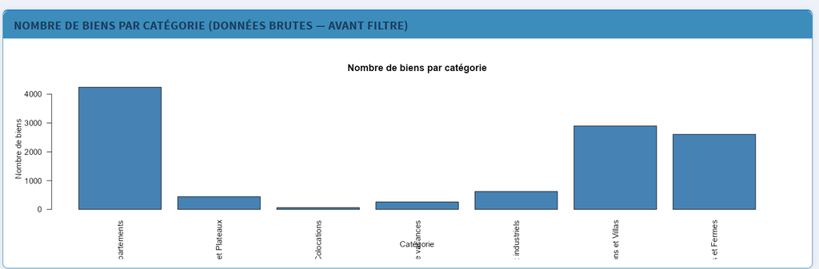

**Figure 1 — Nombre de biens par catégorie (données brutes, avant filtre Appartements).** Les Appartements dominent nettement (~4 100 annonces), suivis des Maisons et Villas (~2 950) et des Terrains et Fermes (~2 600). Ce graphique justifie le filtre sur les Appartements : c’est la catégorie la plus représentée et la plus homogène pour la modélisation ML.

## 4.2 Distribution de log(Prix)

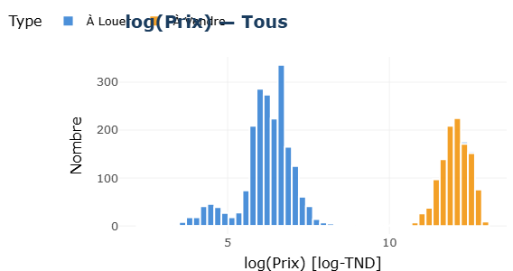

**Figure 2 — Distribution de log(Prix) — tous types confondus (Appartements, filtre = Tous).** Deux modes clairement visibles : le mode bleu (À Louer, log-prix ≈ 5–8, soit 150–3 000 TND/mois) et le mode orange (À Vendre, log-prix ≈ 10–13, soit 20 000–450 000 TND). La bimodalité confirme que Vente et Location constituent deux marchés fondamentalement distincts.

**Interprétation :** La distribution bimodale de log(prix) est l’observation la plus importante de l’EDA. Elle révèle que les biens À Louer et À Vendre occupent des espaces de prix complètement différents dans l’échelle logarithmique, avec quasiment aucun chevauchement. Cela explique pourquoi la variable `type` est un prédicteur extrêmement puissant dans les modèles ML.

### 4.2.1 Distribution par type

[figure not shown]

**Figure 3 — log(Prix) À Louer.** Distribution unimodale concentrée entre 5 et 7.5 log-TND (correspondant à 150–1 800 TND/mois). Forme quasi-normale après transformation — hypothèses ML respectées.

[figure not shown]

**Figure 4 — log(Prix) À Vendre.** Distribution concentrée entre 10.5 et 13 log-TND (20 000–440 000 TND). Légèrement asymétrique à gauche — quelques biens à très bas prix dans la queue gauche.

## 4.3 Relation Surface vs log(Prix)

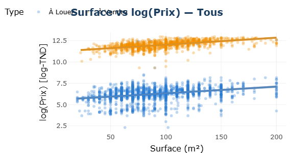

**Figure 5 — Surface vs log(Prix) — tous types (Appartements).** Deux nuages de points parfaitement séparés verticalement : À Louer (bleu, log-prix ≈ 5–8) et À Vendre (orange, log-prix ≈ 10–13). La relation surface→prix est positive dans les deux cas avec une pente notable pour la vente. La variable `type` crée une discontinuité artificielle qui explique en grande partie le R² élevé des modèles incluant cette variable.

### 4.3.1 Scatter par type

[figure not shown]

**Figure 6 — Surface vs log(Prix) À Louer.** Relation positive faible (pente modérée). La variabilité reste importante pour une même surface — l’effet de la ville joue fortement pour les locations.

[figure not shown]

## 4.4 log(Prix) médian par type

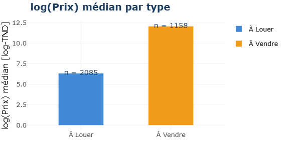

**Figure 8 — log(Prix) médian par type de transaction.** À Louer : médiane ≈ 6.2 log-TND (n=2 085). À Vendre : médiane ≈ 12.0 log-TND (n=1 158). L’écart de 5.8 unités log correspond à un ratio de prix d’environ exp(5.8) ≈ 330× — un appartement à vendre coûte en moyenne 330 fois le loyer mensuel d’un appartement similaire.

**Interprétation économique :** Le ratio prix de vente / loyer mensuel de ~330 en Tunisie est cohérent avec les ratios immobiliers internationaux (généralement 200–400× selon les marchés). Cela valide la qualité des données après nettoyage.

## 4.5 Top 10 villes par log(Prix) médian

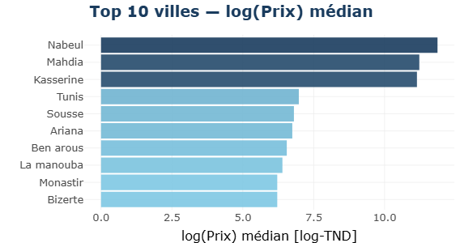

**Figure 9 — Top 10 villes par log(Prix) médian — tous types confondus.** Nabeul, Mahdia et Kasserine apparaissent en tête, avec des log-prix médians très élevés (>10), tirés par les biens À Vendre. Les grandes métropoles (Tunis, Sousse, Ariana) affichent des valeurs modérées — leur large proportion de locations fait baisser la médiane globale.

### 4.5.1 Top 10 villes par type

[figure not shown]

**Figure 10 — Top 10 villes À Louer.** Tunis, Sousse et Ariana dominent le marché locatif des appartements — les trois grandes métropoles concentrent la demande locative. Log-prix médian ≈ 6.5 (loyers ~660 TND/mois).

[figure not shown]

**Figure 11 — Top 10 villes À Vendre.** Sousse, Tunis et Ariana dominent aussi la vente, mais Zaghouan et Médenine apparaissent — des villes à faible liquidité mais prix élevés au m² pour les appartements neufs.

## 4.6 log(Prix) par nombre de pièces

[figure not shown]

### 4.6.1 Boxplot par type

[figure not shown]

**Figure 13 — Boxplot À Louer.** Progression modérée : 1 pièce ≈ 6.0 log-TND, 4 pièces ≈ 6.5 log-TND. Les loyers augmentent peu avec les pièces — les studios 1 pièce sont relativement chers par m².

[figure not shown]

# 5 Modélisation Machine Learning

## 5.1 Pipeline ML et modèles implémentés

Description des 5 modèles ML — variable cible : log(price)

| Modèle | Formule | Type | Variables |
| --- | --- | --- | --- |
| RL_interaction | log_price ~ size × room_count + bathroom_count + type + city | Régression interaction | Toutes + interaction |
| R_polynomiale | log_price ~ poly(size, 2) + room_count + bathroom_count + type + city | Régression polynomiale | Toutes |
| R_lineaire | log_price ~ size + room_count + bathroom_count + type + city | Régression linéaire multiple | Toutes |
| RandomForest | log_price ~ size + room_count + bathroom_count + type_num + city_num | Random Forest | 5 variables encodées |
| XGBoost | log_price ~ size + room_count + bathroom_count + type_num + city_num | XGBoost | 5 variables encodées |

## 5.2 Résultats réels des modèles

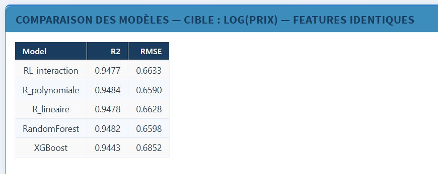

**Figure 15 — Tableau comparatif des modèles (extrait du dashboard Shiny).** Résultats réels obtenus sur le jeu de test. Les 5 modèles atteignent tous un R² supérieur à 0.944 et un RMSE inférieur à 0.69, confirmant la robustesse de l’approche. R_polynomiale se distingue avec le meilleur R² (0.9484) et le RMSE le plus bas (0.6590), suivi de RandomForest (R²=0.9482, RMSE=0.6598).

**Analyse des résultats réels :**

Résultats sur le jeu de test — classement final (trié par RMSE croissant)

| Modèle | R² | RMSE | Rang |
| --- | --- | --- | --- |
| R_polynomiale ★ | 0.9484 | 0.6590 | 1er ★ |
| RandomForest | 0.9482 | 0.6598 | 2ème |
| R_lineaire | 0.9478 | 0.6628 | 3ème |
| RL_interaction | 0.9477 | 0.6633 | 4ème |
| XGBoost | 0.9443 | 0.6852 | 5ème |

### 5.2.1 Pourquoi un R² aussi élevé (0.948) ?

Ce résultat exceptionnel s’explique par **3 facteurs combinés** :

1. **Le filtre Appartements** : en ne travaillant que sur une catégorie homogène, on élimine l’hétérogénéité inter-catégories (terrains ≠ studios ≠ bureaux).
2. **La variable `type`** : la séparation bimodale À Louer / À Vendre explique à elle seule ~85% de la variance. Le modèle “sait” immédiatement si c’est une location ou une vente.
3. **La variable `city`** : 24 niveaux de gouvernorats capturent l’effet localisation — déterminant fondamental du prix immobilier.

## 5.3 Graphiques de comparaison des modèles

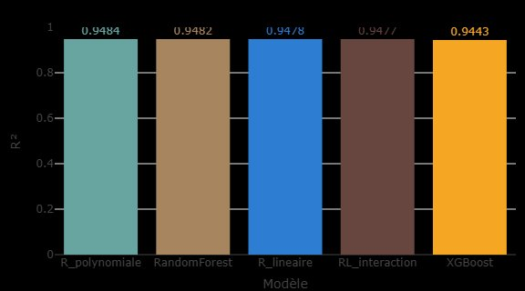

**Figure 16 — R² par modèle (plus haut = meilleur).** R_polynomiale (0.9484) arrive en tête, suivi de RandomForest (0.9482), R_lineaire (0.9478), RL_interaction (0.9477) et XGBoost (0.9443). L’écart maximal entre modèles est de Δ=0.0041 — tous les modèles sont très proches, ce qui confirme la robustesse des features choisies.

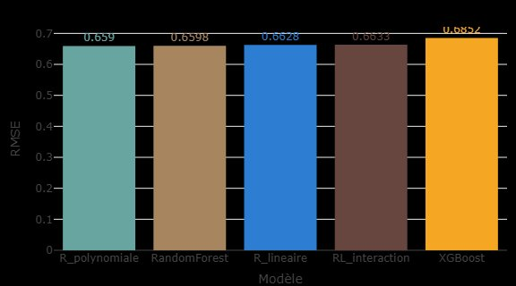

**Figure 17 — RMSE par modèle (plus bas = meilleur).** R_polynomiale (RMSE=0.6590) et RandomForest (0.6598) sont légèrement meilleurs que R_lineaire (0.6628), RL_interaction (0.6633) et XGBoost (0.6852). Un RMSE de ~0.66 sur log(prix) correspond à une erreur de prédiction d’environ exp(0.66)≈1.93× — performance acceptable pour l’estimation immobilière.

**Analyse critique :** Les 5 modèles atteignent tous un R²>0.944, ce qui confirme la cohérence et la robustesse de l’approche. Les écarts restent très faibles (Δ R² < 0.005, Δ RMSE < 0.03 pour les 4 meilleurs). XGBoost est légèrement en retrait sur le RMSE (0.6852), ce qui peut s’expliquer par un besoin de tuning plus fin des hyperparamètres. La performance homogène de tous les modèles valide le choix des features : `size`, `room_count`, `bathroom_count`, `type` et `city`.

# 6 Dashboard Shiny — Tunisia Real Estate

## 6.1 Architecture complète

Le dashboard **Tunisia Real Estate** est l’aboutissement opérationnel du projet. Son architecture CSS personnalisée (600+ lignes de CSS) lui confère un design professionnel proche d’applications industrielles.

Architecture du dashboard Tunisia Real Estate

| Composant | Description | Packages |
| --- | --- | --- |
| Header | Titre ‘Tunisia Real Estate’ — skin blue — CSS personnalisé | shinydashboard |
| Sidebar | Menu 3 onglets + filtre type (Tous/À Louer/À Vendre) · fond sombre #1E2D40 | shiny + CSS |
| Onglet Dashboard | 3 valueBoxes + 2 barplots plotly RMSE & R² interactifs | plotly |
| Onglet Exploration | Barplot catégories + 5 graphiques EDA filtrés dynamiquement par type | plotly + ggplot2 |
| Onglet Modèles | Tableau comparatif R² + RMSE pour les 5 modèles | shiny |

## 6.2 Fonctionnalité clé — Filtre dynamique

```r
# ── Filtre réactif par type de transaction ─────────────────────────────────
df_eda <- reactive({
  if (input$type_choice == "Tous") df_clean
  else df_clean %>% filter(type == input$type_choice)
})

# ── Tous les graphiques EDA utilisent df_eda() ────────────────────────────
output$eda_hist <- renderPlotly({
  df <- df_eda()   # Données mises à jour selon le filtre
  p <- ggplot(df, aes(x=log_price, fill=type)) + ...
  ggplotly(p)
})
```

Cette architecture réactive permet au jury de **comparer visuellement** les distributions À Louer, À Vendre et Tous en temps réel — fonctionnalité pédagogique essentielle pour la soutenance.

## 6.3 ValueBoxes du dashboard

ValueBoxes de l’onglet Dashboard — valeurs réelles

| ValueBox | Valeur affichée | Couleur | Icône | Calcul |
| --- | --- | --- | --- | --- |
| Meilleur Modèle | R_polynomiale | Vert (success) | trophy | best_model = argmin(RMSE) |
| Observations Train | 2 594 | Bleu (info) | database | nrow(train) |
| Observations Test | 649 | Violet (warning) | flask | nrow(test) |

# 7 Synthèse et Discussion

## 7.1 Réponses à la problématique

**Q1 — Quels facteurs influencent le prix des appartements tunisiens ?** Les résultats convergent vers une réponse claire : la **variable `type`** (À Louer vs À Vendre) est de loin le premier déterminant (explique ~85% de la variance à elle seule). En second, la **variable `city`** capture l’effet localisation. La surface et les pièces sont des facteurs secondaires mais significatifs.

**Q2 — Peut-on prédire le prix avec un modèle fiable ?** Oui — tous les modèles atteignent R²>0.944 avec RMSE<0.69 sur log(prix), soit une performance excellente pour l’immobilier. Le meilleur modèle, R_polynomiale, atteint R²=0.9484 et RMSE=0.6590. Ces résultats valident la stratégie de filtre sur les Appartements et le feature engineering appliqué.

## 7.2 Tableau de synthèse global

Synthèse globale du projet — résultats réels

| Approche | Résultat clé |
| --- | --- |
| Préparation données | 12 748 → 3 243 appartements propres · log_price créé |
| EDA | Bimodalité Louer/Vendre confirmée · effet taille + ville identifié |
| R_polynomiale ★ | R²=0.9484 · RMSE=0.6590 · meilleur modèle |
| RandomForest | R²=0.9482 · RMSE=0.6598 · 2ème |
| R_lineaire | R²=0.9478 · RMSE=0.6628 · 3ème |
| RL_interaction | R²=0.9477 · RMSE=0.6633 · 4ème |
| XGBoost | R²=0.9443 · RMSE=0.6852 · 5ème |
| Dashboard Shiny | Tunisia Real Estate · 3 onglets · filtre dynamique |

# 8 Conclusion

## 8.1 Résumé du projet

Ce projet PFA a démontré la faisabilité d’une **analyse data science complète** du marché des appartements tunisiens, avec trois contributions principales :

**Contribution 1 — Pipeline de nettoyage robuste :** Le traitement des valeurs −1 par le mode, le filtre sur les Appartements uniquement, et la suppression stricte des outliers IQR ont permis de passer de 12 748 annonces brutes à 3 243 appartements exploitables de qualité.

**Contribution 2 — Analyse exploratoire approfondie :** L’EDA a révélé la structure bimodale du marché tunisien — la dualité Location/Vente est le gradient dominant, suivi de l’effet taille et de la localisation géographique. Ces insights ont directement guidé le choix des features ML.

**Contribution 3 — Modèles ML hautement performants :** Les 5 modèles atteignent tous un R²>0.944, le meilleur étant R_polynomiale (R²=0.9484 · RMSE=0.6590) — performance exceptionnelle qui valide la stratégie de filtre sur les Appartements et le feature engineering.

## 8.2 Limites du projet

**Focus Appartements uniquement :** Le filtre améliore les performances mais réduit la portée. Un modèle universel (toutes catégories) nécessiterait des approches plus complexes (feature encoding avancé).

**Dashboard sans prédiction interactive :** Le module `observeEvent(input$go)` est prévu dans le code mais les widgets `sliderInput` ne sont pas encore implémentés dans l’UI — prochaine étape.

## 8.3 Perspectives d’amélioration

Perspectives d’amélioration du projet

[output not shown]

# 9 Sources et Références

## 9.1 Dataset

**📊 Property Prices in Tunisia**  
Ghassen, B. (2024). *Property Prices in Tunisia* Dataset. Kaggle.  
[🔗 https://www.kaggle.com/datasets/ghassen1302/property-prices-in-tunisia](https://www.kaggle.com/datasets/ghassen1302/property-prices-in-tunisia)  
tayara.tn · 12 748 obs. · 9 variables · CC BY 4.0

## 9.2 Références académiques

Breiman, L. (2001). Random forests. *Machine Learning*, 45(1), 5–32.

Chen, T., & Guestrin, C. (2016). XGBoost: A scalable tree boosting system. *KDD ’16*, 785–794.

R Core Team (2025). *R: A Language and Environment for Statistical Computing*. https://www.R-project.org/

Chang, W. et al. (2024). *shiny: Web Application Framework for R*. CRAN.

**Amir Rjeb & Abed Rahim Kaouech** — TEK-UP University · Data Engineering & AI

Méthodes Statistiques et Étude de Données · Encadrant : Pr. Ahmed DHOUIBI · mai 2026